# Test_MEFISTO_aging

## PCA as a quality control

```r
data_wide <- spread(filtered_data, key = age_group, value = mean)
head(data_wide)
```

```
## # A tibble: 6 × 11
## # Groups:   ensembl_id [6]
##   ensembl_id      `0`  `10`   `20`  `30`  `40`    `50`   `60`   `70`  `80`  `90`
##   <chr>         <dbl> <dbl>  <dbl> <dbl> <dbl>   <dbl>  <dbl>  <dbl> <dbl> <dbl>
## 1 ENSG0000000… 1.23   1.18  1.56   1.30  1.97  1.49    1.90   1.13   1.99  1.86
## 2 ENSG0000000… 0.123  0.277 0.431  0.461 0.565 0.361   0.526  0.608  0.722 1.24
## 3 ENSG0000000… 3.41   3.62  3.33   3.34  3.42  3.39    3.54   3.32   3.35  2.63
## 4 ENSG0000000… 0.361  1.08  0.674  0.863 1.12  1.08    0.948  1.09   1.11  1.50
## 5 ENSG0000000… 2.27   2.29  2.20   2.23  2.21  2.09    2.15   2.08   2.09  1.50
## 6 ENSG0000000… 0.0108 0     0.0935 0.145 0.229 0.00995 0.0800 0.0164 0.562 0.675
```

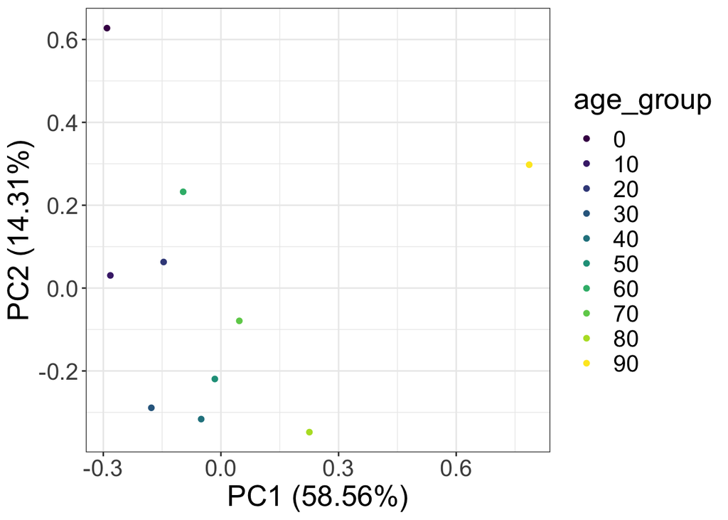

```r
df_pca <- ungroup(data_wide)%>%
  subset(select = -c(ensembl_id))%>%
  t() %>%
  data.frame()%>%
  mutate(age_group = colnames(data_wide[-1])) %>%
  mutate(age_group = factor(age_group, levels = age_group, order = TRUE))

pca <- prcomp(df_pca[, 1:ncol(df_pca)-1])
autoplot(pca, data = df_pca, colour = "age_group")  +
  theme_bw() +
  theme(text = element_text(size = 20))
```

# MEFISTO

## Create MEFISTO object

```r
df_mefisto <- subset(filtered_data, select = c("age_group", "ensembl_id", "mean")) %>%
  mutate(view = "single_view")
colnames(df_mefisto) <- c("sample", "feature", "value", "view")
head(df_mefisto)
```

```
## # A tibble: 6 × 4
## # Groups:   feature [6]
##   sample feature          value view
##    <int> <chr>            <dbl> <chr>
## 1      0 ENSG00000000971 1.23   single_view
## 2      0 ENSG00000001561 0.123  single_view
## 3      0 ENSG00000002330 3.41   single_view
## 4      0 ENSG00000002745 0.361  single_view
## 5      0 ENSG00000002822 2.27   single_view
## 6      0 ENSG00000002933 0.0108 single_view
```

```r
# df with the corresponding covariate (age) for each sample
time <- data.frame(sample = age, covariate = "age", value =  age)
```

```r
mefisto <- create_mofa(df_mefisto)
```

```
## Creating MOFA object from a data.frame...
```

```r
mefisto <- set_covariates(mefisto, covariates = time)
print(mefisto)
```

```
## Untrained MEFISTO model with the following characteristics:
##  Number of views: 1
##  Views names: single_view
##  Number of features (per view): 2000
##  Number of groups: 1
##  Groups names: single_group
##  Number of samples (per group): 10
##  Number of covariates per sample: 1
##
```

## Define options

```r
data_opts <- get_default_data_options(mefisto)

model_opts <- get_default_model_options(mefisto)
model_opts$num_factors <- 3

train_opts <- get_default_training_options(mefisto)

mefisto_opts <- get_default_mefisto_options(mefisto)

mefisto <- prepare_mofa(mefisto, model_options = model_opts,
                   mefisto_options = mefisto_opts,
                   training_options = train_opts,
                   data_options = data_opts)
```

```
## Checking data options...
```

```
## Checking training options...
```

```
## Checking model options...
```

```
## Checking inference options for mefisto covariates...
```

## Build and train the MOFA object

```r
outfile = (paste0(file_path, "models/test_model_3f.hdf5"))
trained_model <- run_mofa(mefisto, outfile)
```

[output not shown]

```
## Connecting to the mofapy2 package using basilisk.
##     Set 'use_basilisk' to FALSE if you prefer to manually set the python binary using 'reticulate'.
```

# Downstream Analysis

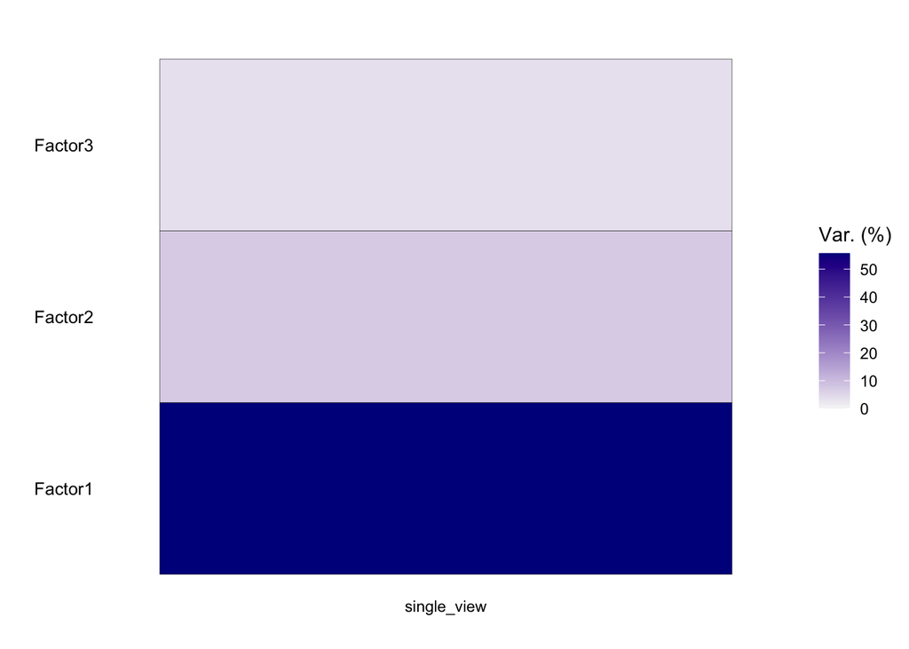

```r
plot_variance_explained(trained_model)
```

```r
get_scales(trained_model)
```

```
##   Factor1   Factor2   Factor3
## 0.9771507 0.9942973 0.0000000
```

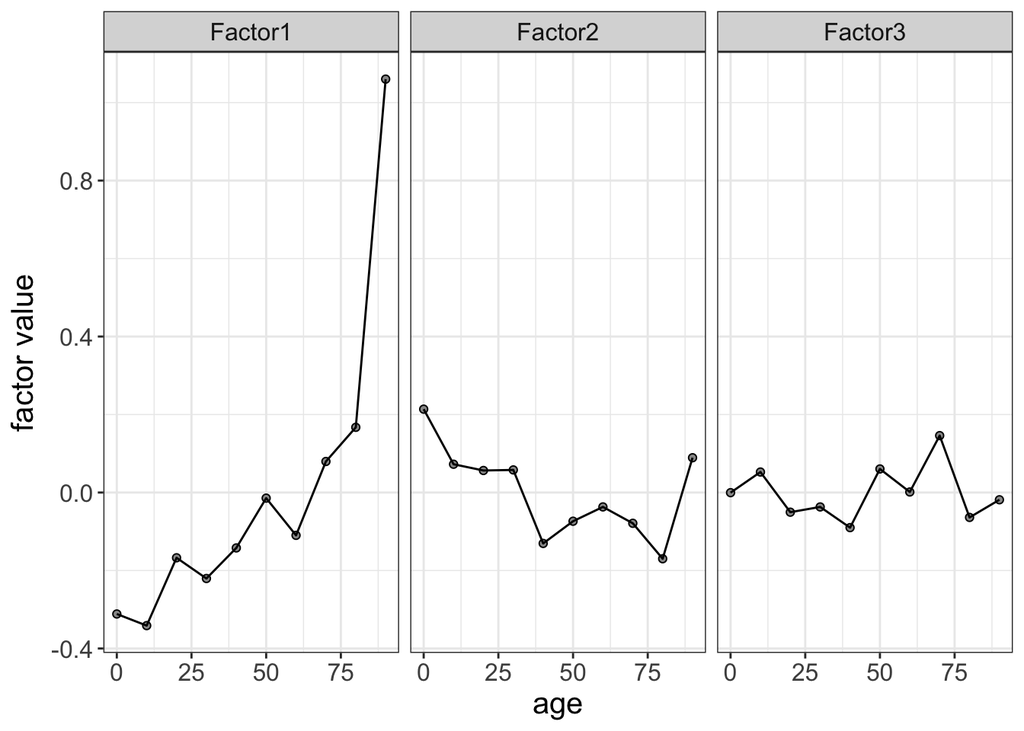

```r
plot_factors_vs_cov(trained_model) +
  geom_line()+
  theme_bw()+
  theme(text = element_text(size = 15))
```

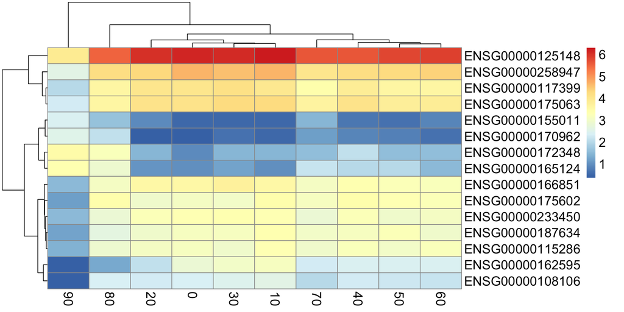

```r
plot_data_heatmap(trained_model,
  view = "single_view",         # view of interest
  factor = 1,             # factor of interest
  features = 15,          # number of features to plot (they are selected by weight)

  # extra arguments that are passed to the `pheatmap` function
  cluster_rows = TRUE, cluster_cols = TRUE,
  show_rownames = TRUE, show_colnames = TRUE, fontsize = 15)
```

# GSEA with reactome gene sets

## Load reactomeGS

```r
utils::data("reactomeGS")
head(rownames(reactomeGS))
```

```
## [1] "Interleukin-6 signaling"
## [2] "Apoptosis"
## [3] "Hemostasis"
## [4] "Intrinsic Pathway for Apoptosis"
## [5] "Cleavage of Growing Transcript in the Termination Region "
## [6] "PKB-mediated events"
```

```r
head(colnames(reactomeGS))
```

```
## [1] "ENSG00000187634" "ENSG00000188976" "ENSG00000187961" "ENSG00000187583"
## [5] "ENSG00000187642" "ENSG00000188290"
```

## Run GSEA on positive weights

```r
enrichment.parametric <- run_enrichment(trained_model,
  view = "all", factors = 1:3,
  feature.sets = reactomeGS,
  sign = "positive",
  statistical.test = "parametric"
)
```

```
## Intersecting features names in the model and the gene set annotation results in a total of 1907 features.
```

```
##
## Running feature set Enrichment Analysis with the following options...
## View: single_view
## Number of feature sets: 315
## Set statistic: mean.diff
## Statistical test: parametric
```

```
## Subsetting weights with positive sign
```

**Factor 1**

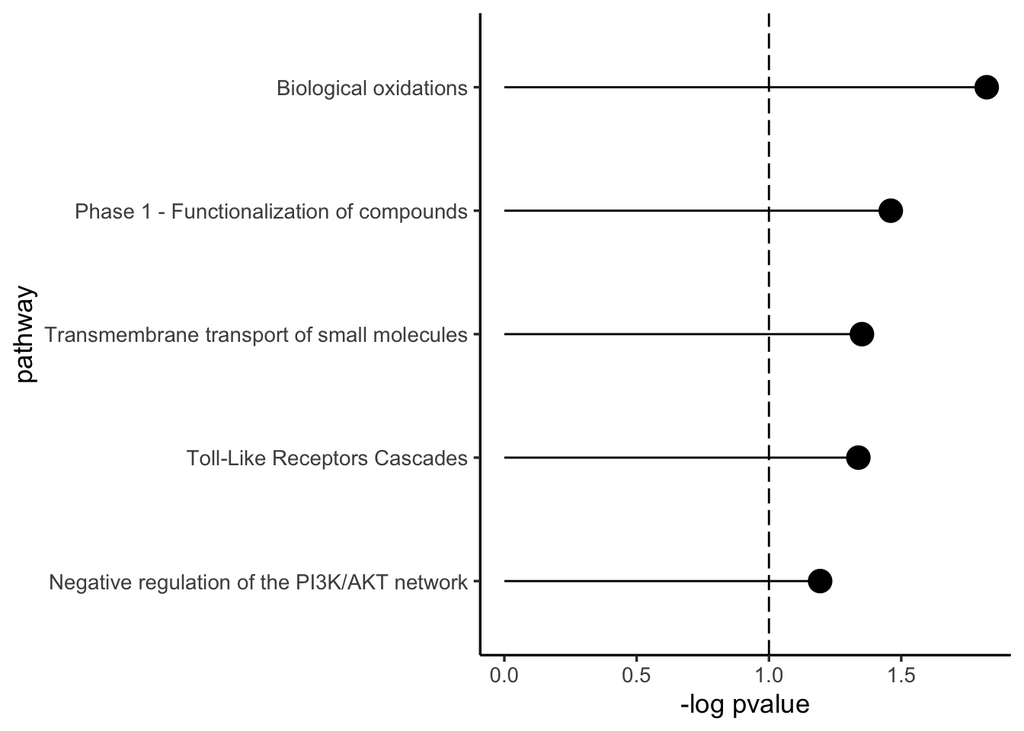

```r
plot_enrichment(enrichment.parametric,
  factor = 1,
  max.pathways = 5) +
  theme_classic(base_size = 13)
```

## Run GSEA on negative weights

```r
enrichment.parametric <- run_enrichment(trained_model,
  view = "all", factors = 1:3,
  feature.sets = reactomeGS,
  sign = "negative",
  statistical.test = "parametric"
)
```

```
## Intersecting features names in the model and the gene set annotation results in a total of 1907 features.
```

```
##
## Running feature set Enrichment Analysis with the following options...
## View: single_view
## Number of feature sets: 315
## Set statistic: mean.diff
## Statistical test: parametric
```

```
## Subsetting weights with negative sign
```

**Factor 1**

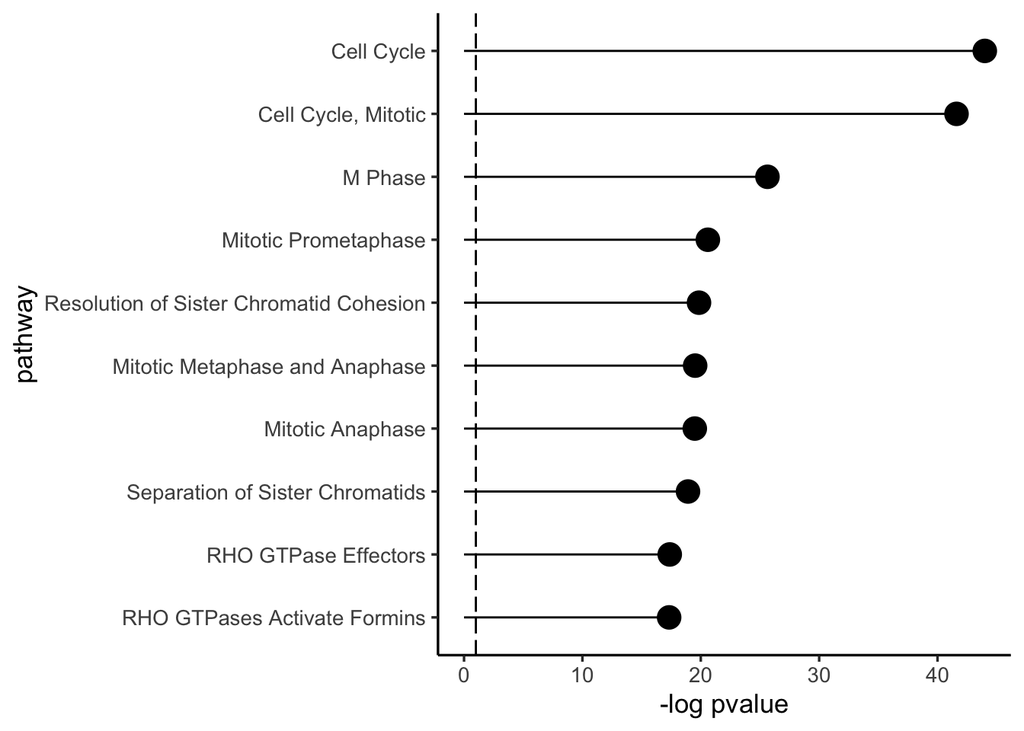

```r
plot_enrichment(enrichment.parametric,
  factor = 1,
  max.pathways = 10) +
  theme_classic(base_size = 13)
```

# GSEA with MSigDB gene sets

## Run GSEA on weights with positive sign

```r
utils::data("MSigDB_v6.0_C5_human")
enrichment.parametric <- run_enrichment(trained_model,
  view = "all", factors = 1:3,
  feature.sets = MSigDB_v6.0_C5_human,
  sign = "positive",
  statistical.test = "parametric"
)
```

```
## Intersecting features names in the model and the gene set annotation results in a total of 1897 features.
```

```
##
## Running feature set Enrichment Analysis with the following options...
## View: single_view
## Number of feature sets: 1527
## Set statistic: mean.diff
## Statistical test: parametric
```

```
## Subsetting weights with positive sign
```

**Factor 1**

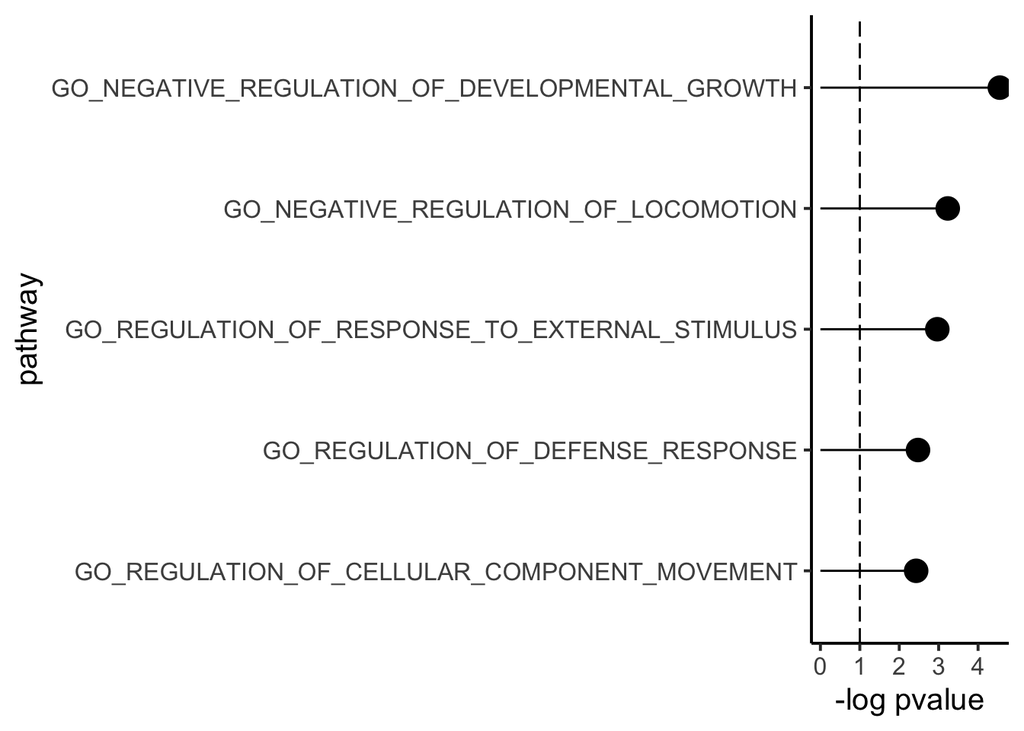

```r
plot_enrichment(enrichment.parametric,
  factor = 1,
  max.pathways = 5) +
  theme_classic(base_size = 15)
```

```r
utils::data("MSigDB_v6.0_C5_human")
enrichment.parametric <- run_enrichment(trained_model,
  view = "all", factors = 1:3,
  feature.sets = MSigDB_v6.0_C5_human,
  sign = "negative",
  statistical.test = "parametric"
)
```

```
## Intersecting features names in the model and the gene set annotation results in a total of 1897 features.
```

```
##
## Running feature set Enrichment Analysis with the following options...
## View: single_view
## Number of feature sets: 1527
## Set statistic: mean.diff
## Statistical test: parametric
```

```
## Subsetting weights with negative sign
```

**Factor 1**

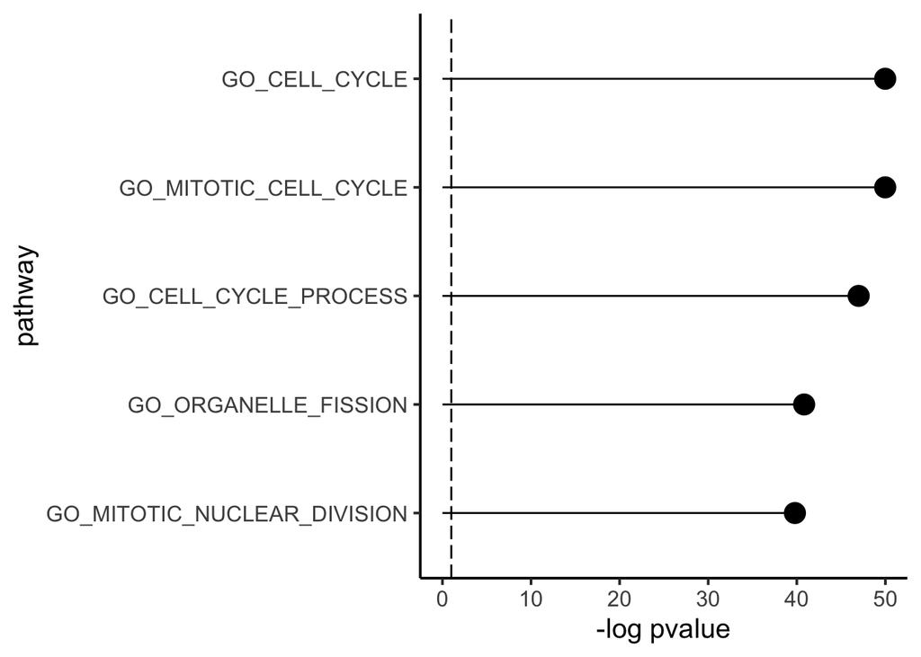

```r
plot_enrichment(enrichment.parametric,
  factor = 1,
  max.pathways = 5) +
  theme_classic(base_size = 15)
```

# Genes with highest weights

## Get weight matrix

```r
weights <- get_weights(trained_model, views = "all", factors = "all", scale = F, as.data.frame = TRUE) %>%
  group_by(factor, view) %>%
  mutate(value = value/max(abs(value))) %>%
  ungroup()
colnames(weights) <- c("ensembl_id", "factor", "value", "view")
weights <- weights[order(abs(weights$value), decreasing = TRUE), ] %>%
  left_join(subset(gene_annotations, select = c(ensembl_id, symbol, description)))
head(weights)
```

```
## # A tibble: 6 × 6
##   ensembl_id      factor   value view        symbol  description
##   <chr>           <fct>    <dbl> <fct>       <chr>   <chr>
## 1 ENSG00000125148 Factor1 -1     single_view MT2A    metallothionein 2A [Source…
## 2 ENSG00000124212 Factor2 -1     single_view PTGIS   prostaglandin I2 synthase …
## 3 ENSG00000049323 Factor3  1     single_view LTBP1   latent transforming growth…
## 4 ENSG00000162595 Factor1 -0.997 single_view DIRAS3  DIRAS family GTPase 3 [Sou…
## 5 ENSG00000165124 Factor1  0.974 single_view SVEP1   sushi, von Willebrand fact…
## 6 ENSG00000091622 Factor2 -0.971 single_view PITPNM3 PITPNM family member 3 [So…
```

## Genes with highest weights in factor 1

```r
selected_genes_pos <- filter(weights, factor == "Factor1") %>%
  top_n(5, value)
selected_genes_neg <- filter(weights, factor == "Factor1") %>%
  top_n(5, -value)
selected_genes <- bind_rows(selected_genes_pos, selected_genes_neg)

selected_genes
```

```
## # A tibble: 10 × 6
##    ensembl_id      factor   value view        symbol    description
##    <chr>           <fct>    <dbl> <fct>       <chr>     <chr>
##  1 ENSG00000165124 Factor1  0.974 single_view SVEP1     sushi, von Willebrand f…
##  2 ENSG00000170962 Factor1  0.882 single_view PDGFD     platelet derived growth…
##  3 ENSG00000155011 Factor1  0.826 single_view DKK2      dickkopf WNT signaling …
##  4 ENSG00000172348 Factor1  0.810 single_view RCAN2     regulator of calcineuri…
##  5 ENSG00000164761 Factor1  0.797 single_view TNFRSF11B TNF receptor superfamil…
##  6 ENSG00000125148 Factor1 -1     single_view MT2A      metallothionein 2A [Sou…
##  7 ENSG00000162595 Factor1 -0.997 single_view DIRAS3    DIRAS family GTPase 3 […
##  8 ENSG00000166851 Factor1 -0.908 single_view PLK1      polo like kinase 1 [Sou…
##  9 ENSG00000108106 Factor1 -0.893 single_view UBE2S     ubiquitin conjugating e…
## 10 ENSG00000117399 Factor1 -0.886 single_view CDC20     cell division cycle 20 …
```

**Plot expression of selected genes during aging**

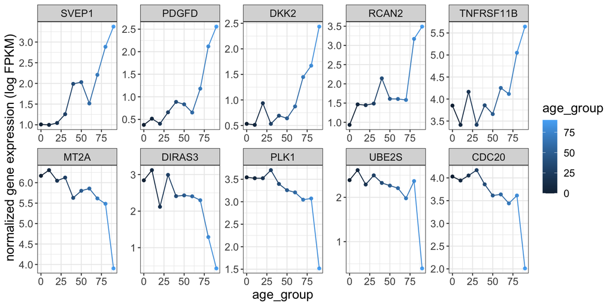

```r
df_plot = data_mean %>%
  left_join(subset(gene_annotations, select = c(ensembl_id, symbol))) %>%
  filter(ensembl_id %in% selected_genes$ensembl_id) %>%
  mutate(symbol = factor(symbol, levels = selected_genes$symbol))
ggplot(df_plot, aes(x = age_group, y = mean, col = age_group)) +
    geom_point() +
    geom_line() +
    facet_wrap(~ symbol, scales = "free", ncol = 5) +
    theme(axis.text.x = element_blank(), axis.ticks.x = element_blank()) +
    labs(y = "normalized gene expression (log FPKM)")  +
    theme_bw() +
    theme(text = element_text(size = 15))
```

DIRAS3: “This gene encodes a member of the ras superfamily. This gene is imprinted gene with monoallelic expression of the paternal allele which is associated with growth suppression. The encoded protein acts as a tumor suppressor” https://www.genecards.org/cgi-bin/carddisp.pl?gene=DIRAS3

MT2A: “MT2A is crucial for the immune efficiency during aging and age-related diseases” https://www.ncbi.nlm.nih.gov/pmc/articles/PMC5037761/

PLK1: “The Ser/Thr protein kinase encoded by this gene belongs to the CDC5/Polo subfamily. It is highly expressed during mitosis and elevated levels are found in many different types of cancer. Depletion of this protein in cancer cells dramatically inhibited cell proliferation and induced apoptosis; hence, it is a target for cancer therapy.” https://www.genecards.org/cgi-bin/carddisp.pl?gene=PLK1

SVEP1: “SVEP1 has emerged as a novel circulating biomarker of age and longevity in humans” https://longerlife.org/research/stitziel-targeting-receptor-interactions-with-svep1-261

**Save 10% of genes with highest positive and negative weight in factor 1**

```r
weights_f1 <- filter(weights, factor == "Factor1")
# Select genes with highest positive weight
top_genes_pos <- weights_f1 %>%
  top_frac(0.1, value) %>%
  left_join(subset(gene_annotations, select = c(ensembl_id, chr, start, end)), by = "ensembl_id") %>%
  mutate(locus = paste0("chr_", chr, "_loc_",
                        plyr::round_any(start, 250000, floor))) %>%
  subset(select = c(ensembl_id, value, symbol, locus))

# Select genes with highest negative weight
top_genes_neg <- weights_f1 %>%
  top_frac(0.1, -value) %>%
  left_join(subset(gene_annotations, select = c(ensembl_id, chr, start, end)), by = "ensembl_id") %>%
  mutate(locus = paste0("chr_", chr, "_loc_",
                        plyr::round_any(start, 250000, floor))) %>%
  subset(select = c(ensembl_id, value, symbol, locus))

top_genes <- bind_rows(top_genes_pos, top_genes_neg)
head(top_genes)
```

```
## # A tibble: 6 × 4
##   ensembl_id      value symbol    locus
##   <chr>           <dbl> <chr>     <chr>
## 1 ENSG00000165124 0.974 SVEP1     chr_9_loc_110250000
## 2 ENSG00000170962 0.882 PDGFD     chr_11_loc_103750000
## 3 ENSG00000155011 0.826 DKK2      chr_4_loc_106750000
## 4 ENSG00000172348 0.810 RCAN2     chr_6_loc_46000000
## 5 ENSG00000164761 0.797 TNFRSF11B chr_8_loc_118750000
## 6 ENSG00000102760 0.792 RGCC      chr_13_loc_41250000
```

```r
# Save as csv
write.csv(top_genes_pos, paste0(file_path, "Data/top_genes_pos_0.1.csv"), row.names = FALSE)
write.csv(top_genes_neg, paste0(file_path, "Data/top_genes_neg_0.1.csv"), row.names = FALSE)
```

**Distribution of weights in factor 1**

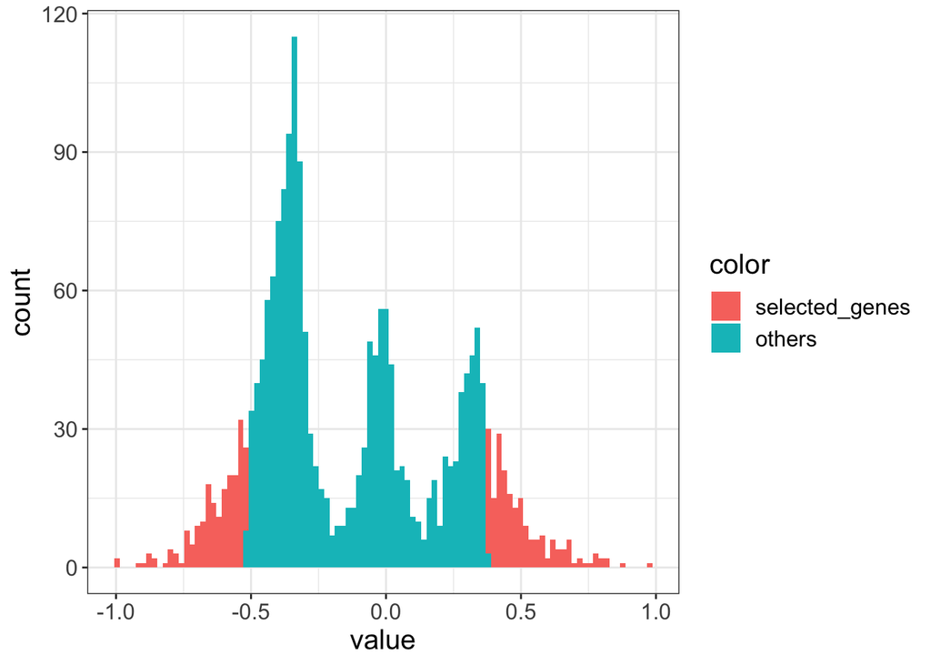

```r
weights_f1$color <- factor(ifelse(weights_f1$symbol %in% top_genes$symbol,
                                  'selected_genes', 'others'),
                           levels = c('selected_genes', 'others'))
ggplot(weights_f1, aes(x = value, fill = color)) +
  geom_histogram(bins = 100) +
  theme_bw() +
  theme(text = element_text(size = 15))
```

```r
# Number of genes with positive weight
length(unique(filter(weights_f1, value > 0)$ensembl_id))
```

```
## [1] 695
```

```r
# Number of genes with negative weight
length(unique(filter(weights_f1, value < 0)$ensembl_id))
```

```
## [1] 1305
```

## Comparison with active loci in IMR90 and GM23248

```r
IMR90 <- read.csv(paste0(file_path, "Data/IMR90_cosine_wo_PC.txt")) %>%
  rename(locus = X0) %>%
  mutate(young_activity = "young-active")
old_fibroblasts <- read.csv(paste0(file_path, "Data/old_fibroblasts_cosine_wo_PC.txt")) %>%
  rename(locus = X0) %>%
  mutate(old_activity = "old-active")

# add for each gene whether corresponding loci is active or inactive based on the HiC clustering in IMR90 and GM23248
activity <- top_genes_pos %>%
  mutate(sign = 'positive') %>%
  bind_rows(top_genes_neg %>% mutate(sign = 'negative')) %>%
  mutate(sign = factor(sign, levels = c('positive', 'negative'))) %>%
  left_join(IMR90) %>%
  replace_na(list(young_activity = "young-inactive")) %>%
  left_join(old_fibroblasts) %>%
  replace_na(list(old_activity = "old-inactive")) %>%
  mutate(development = factor(paste0(young_activity, "_", old_activity),
        levels = c("young-active_old-active", "young-active_old-inactive", "young-inactive_old-active", "young-inactive_old-inactive")))
head(activity)
```

```
## # A tibble: 6 × 8
##   ensembl_id    value symbol locus sign  young_activity old_activity development
##   <chr>         <dbl> <chr>  <chr> <fct> <chr>          <chr>        <fct>
## 1 ENSG00000165… 0.974 SVEP1  chr_… posi… young-active   old-active   young-acti…
## 2 ENSG00000170… 0.882 PDGFD  chr_… posi… young-active   old-inactive young-acti…
## 3 ENSG00000155… 0.826 DKK2   chr_… posi… young-inactive old-active   young-inac…
## 4 ENSG00000172… 0.810 RCAN2  chr_… posi… young-inactive old-active   young-inac…
## 5 ENSG00000164… 0.797 TNFRS… chr_… posi… young-active   old-active   young-acti…
## 6 ENSG00000102… 0.792 RGCC   chr_… posi… young-active   old-active   young-acti…
```

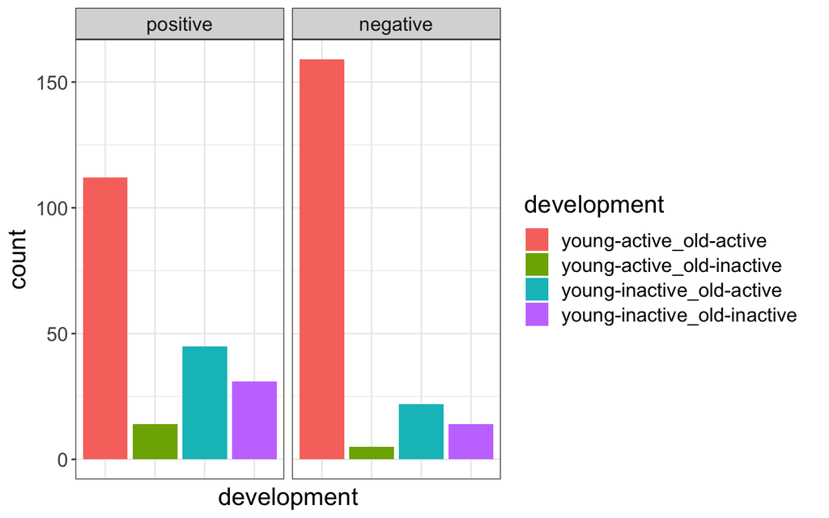

```r
ggplot(activity, aes(x = development, fill = development)) +
  geom_bar() +
  facet_wrap(~sign) +
  theme_bw() +
  theme(axis.text.x=element_blank(),
        axis.ticks.x=element_blank()) +
  theme(text = element_text(size = 17))
```

## Linear regression

**Linear regression of top 10 genes**

```r
selected_genes <- filter(weights, factor == "Factor1") %>%
  top_n(10, abs(value))

df = data_long %>%
  left_join(subset(gene_annotations, select = c(ensembl_id, symbol))) %>%
  filter(ensembl_id %in% selected_genes$ensembl_id) %>%
  subset(select = c(id, age, symbol, value)) %>%
  mutate(value = log(value + 1)) %>%
  spread(key = symbol, value = value)
model <- lm(age ~ ., subset(df, select = -id))
summary(model)
```

```
##
## Call:
## lm(formula = age ~ ., data = subset(df, select = -id))
##
## Residuals:
##     Min      1Q  Median      3Q     Max
## -46.810 -13.765  -1.374  11.017  50.835
##
## Coefficients:
##             Estimate Std. Error t value     Pr(>|t|)
## (Intercept)  124.990     21.619   5.782 0.0000000521 ***
## CCDC85B       14.028      5.520   2.541     0.012216 *
## CDC20        -20.257     18.458  -1.097     0.274473
## DIRAS3         4.803      2.732   1.758     0.081095 .
## MT2A         -19.405      4.296  -4.517 0.0000139085 ***
## PDGFD         -4.026      5.122  -0.786     0.433310
## PLK1          13.460     20.773   0.648     0.518149
## SAMD11       -14.557      4.091  -3.558     0.000522 ***
## SVEP1         13.516      4.349   3.108     0.002318 **
## TUBB3          2.294      6.479   0.354     0.723868
## UBE2S         11.188      8.144   1.374     0.171873
## ---
## Signif. codes:  0 '***' 0.001 '**' 0.01 '*' 0.05 '.' 0.1 ' ' 1
##
## Residual standard error: 21.75 on 130 degrees of freedom
## Multiple R-squared:  0.5061, Adjusted R-squared:  0.4682
## F-statistic: 13.32 on 10 and 130 DF,  p-value: 0.0000000000000007311
```

**LASSO**

```r
df = data_long %>%
  subset(select = c(id, age, ensembl_id, value)) %>%
  mutate(value = log(value + 1)) %>%
  filter(ensembl_id %in% filtered_data$ensembl_id) %>%
  spread(key = ensembl_id, value = value)

model <- glmnet(subset(df, select = -c(id, age)), df$age, alpha = 1, lambda = 0.01)
lasso <- data.frame(ensembl_id = dimnames(coef(model))[[1]], coefficient = matrix(coef(model))) %>%
  filter(coefficient != 0) %>%
  left_join(subset(gene_annotations, select = c(ensembl_id, symbol))) %>%
  filter(ensembl_id != "(Intercept)")
head(lasso)
```

```
##        ensembl_id coefficient   symbol
## 1 ENSG00000000971    5.407678      CFH
## 2 ENSG00000001561    3.281738    ENPP4
## 3 ENSG00000002330   -4.783402      BAD
## 4 ENSG00000002745    2.078323    WNT16
## 5 ENSG00000002822   -7.268714   MAD1L1
## 6 ENSG00000002933    6.865234 TMEM176A
```

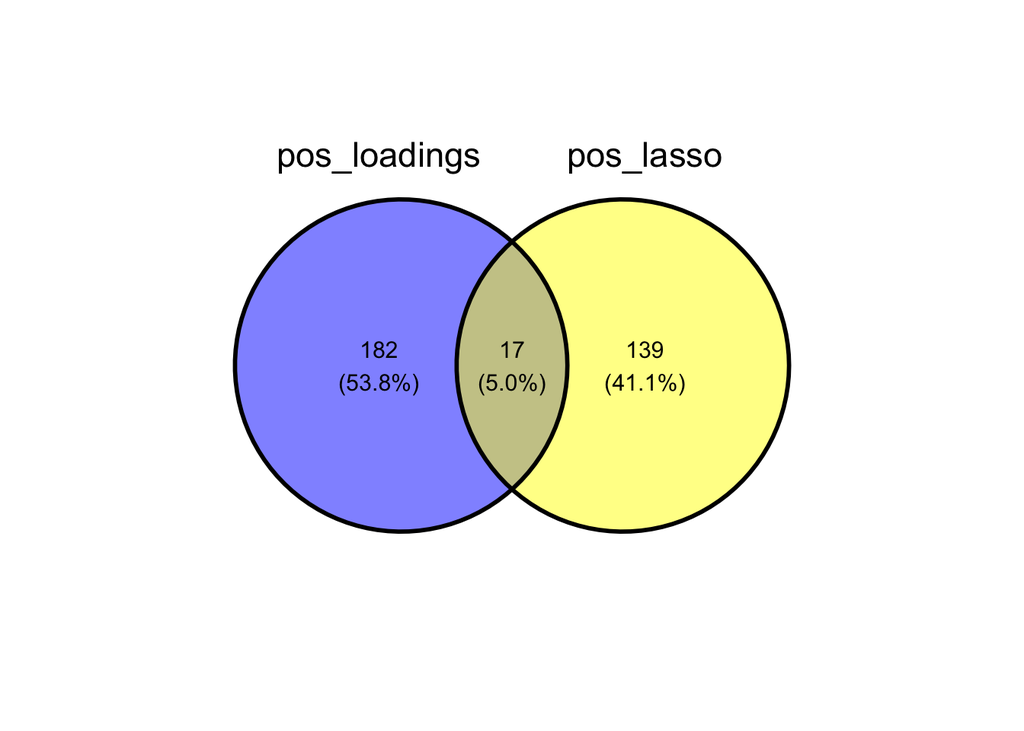

```r
ggvenn(list(pos_loadings = top_genes_pos$symbol, pos_lasso = filter(lasso, coefficient > 0)$symbol)) +
    theme(text = element_text(size = 15))
```

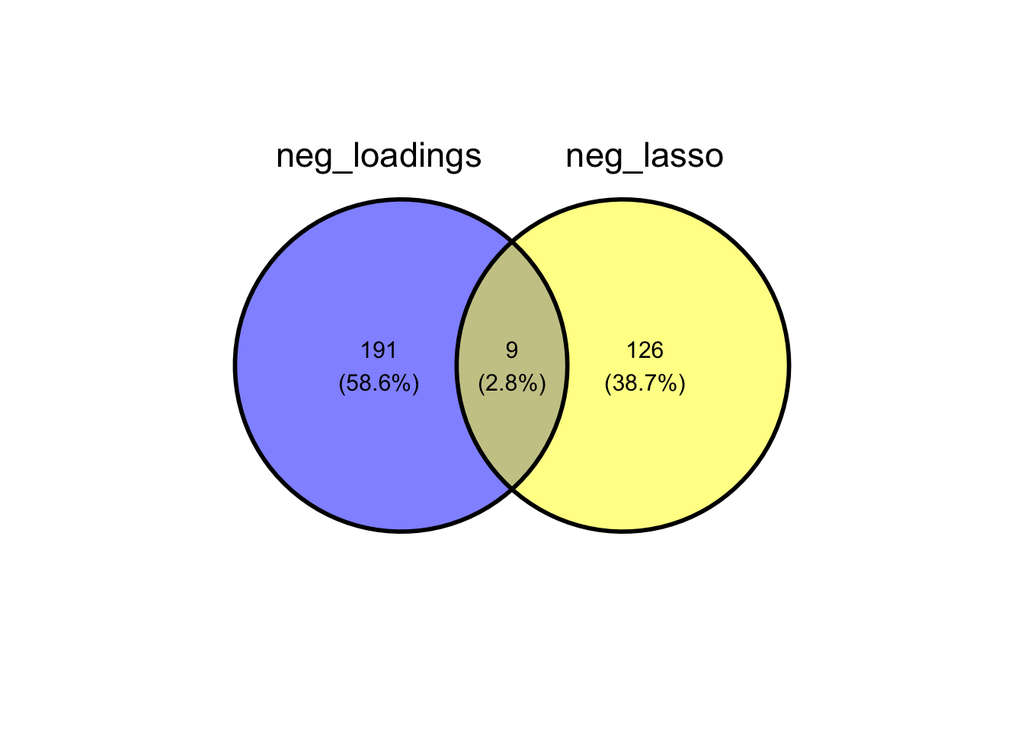

```r
ggvenn(list(neg_loadings = top_genes_neg$symbol, neg_lasso = filter(lasso, coefficient < 0)$symbol)) +
    theme(text = element_text(size = 15))
```

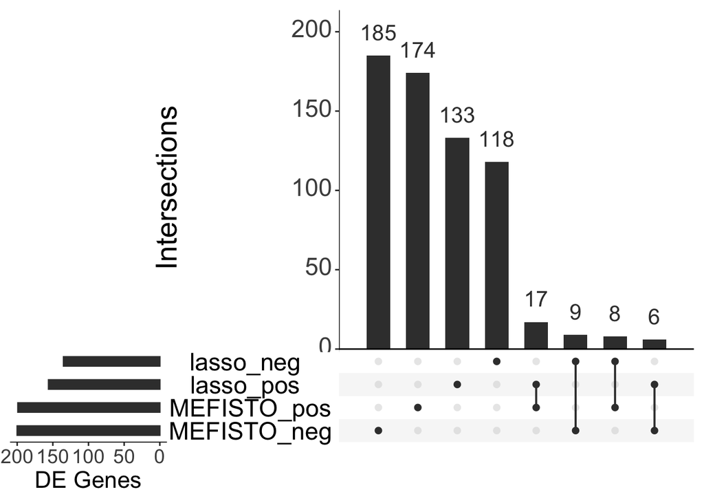

```r
list = list(MEFISTO_pos = top_genes_pos$symbol, lasso_pos = filter(lasso, coefficient > 0)$symbol,
            MEFISTO_neg = top_genes_neg$symbol, lasso_neg = filter(lasso, coefficient < 0)$symbol)

upset(fromList(list), order.by = "freq", nsets = 4,
       mainbar.y.label = "Intersections", sets.x.label = "DE Genes",
       text.scale = c(2.5, 2.5, 2, 2, 2.5, 2.5), nintersects = 10)
```

## Compare with genes in adhesome

```r
adhesome <- read.csv(paste0(file_path, 'Data/adhesome_loci.csv'))
head(adhesome)
```

```
##     X chrom chrom_int loci   gene
## 1  34  chr1         1   65 FBLIM1
## 2  97  chr1         1   96  ASAP3
## 3 173  chr1         1  110 SLC9A1
## 4 158  chr1         1  128  FABP3
## 5 139  chr1         1  159  MACF1
## 6 139  chr1         1  160  MACF1
```

**Intersection of genes in the adhesome with the top weighted genes**

```r
length(which(activity$symbol %in% adhesome$gene))
```

```
## [1] 8
```